# Final project

Iceland housing data analysis

Rakel María Brynjólfsdóttir

4/5/2018

## Data preprocessing

- The data consists of about 40 000 properties sold in Iceland from 2008-2017
- We used only properties in the capital region
- We used 5 levels of the $\texttt{teg_eign}$ variable
- Combined levels for many of the factors and dropped those with few observations
- Changed $\texttt{kdagur}$ to days since bought
- Changed $\texttt{byggar}$ to age of house in years
- Removed redundant variables

## Descriptive plots

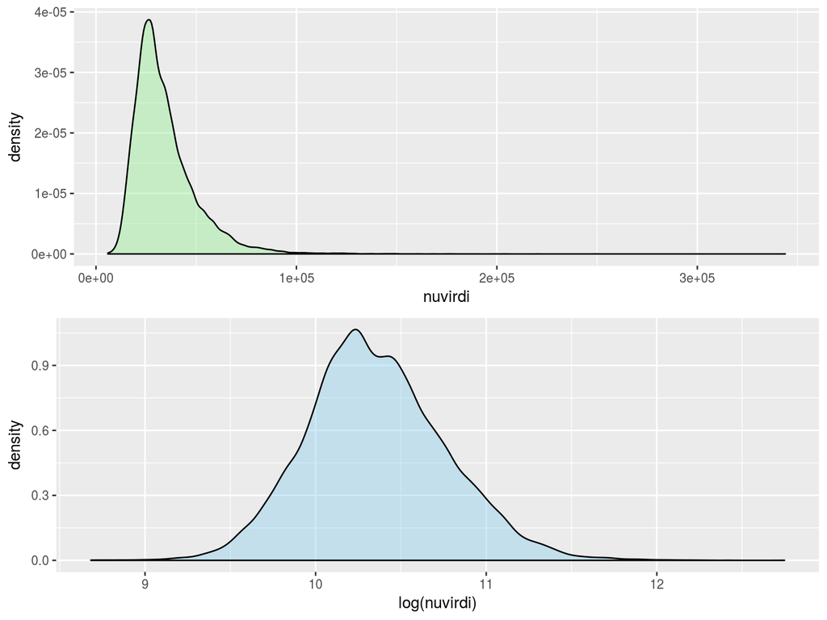

## Transformations - ibm2

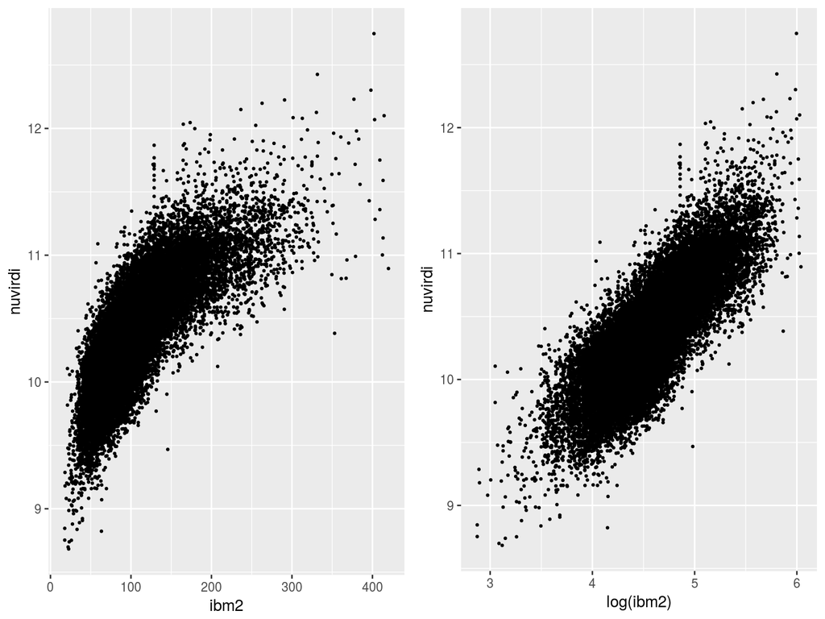

## Transformations - geymm2

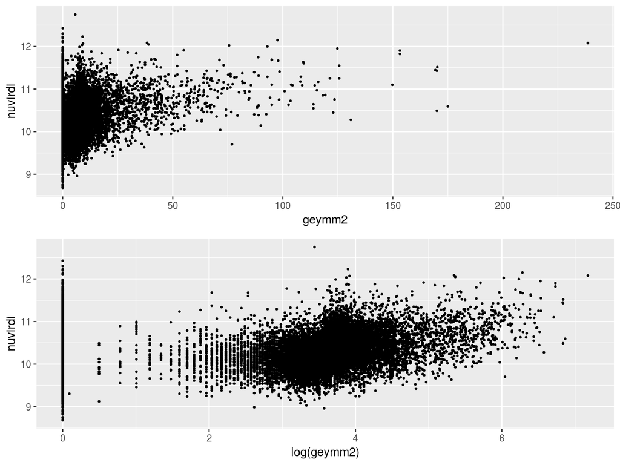

For all methods we predicted on both the log-transformed data and the untransformed data.

## Correlation plot

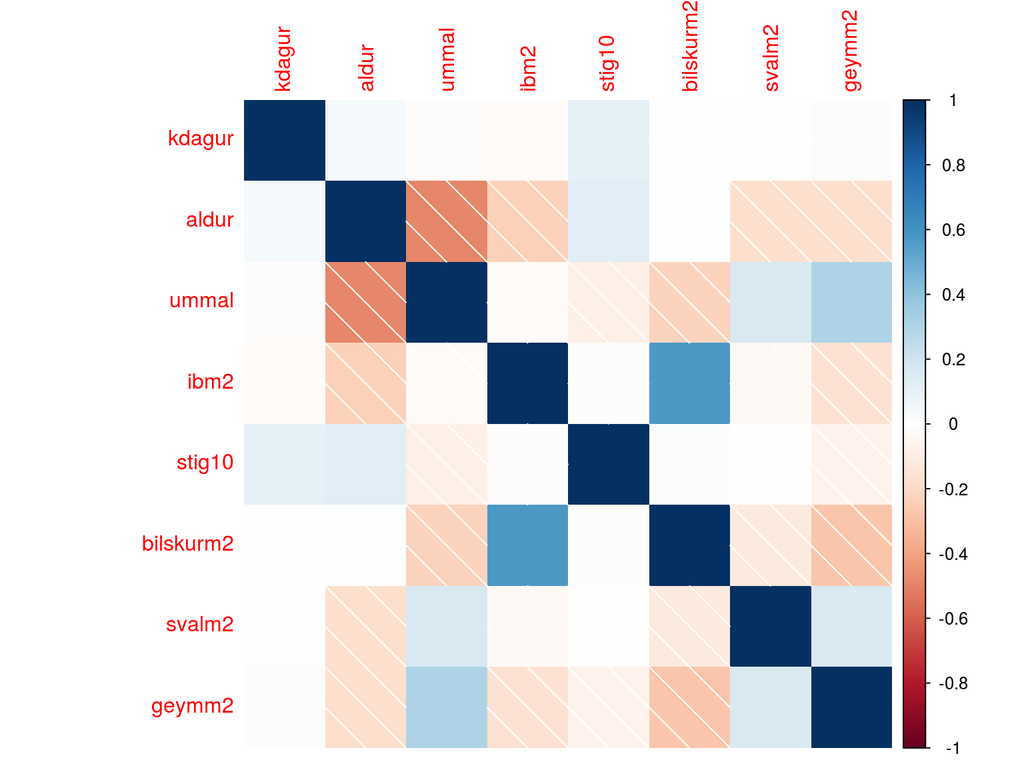

## Methods

We used the following methods to predict $\texttt{nuvirdi}$:

- Linear Regression
- Lasso Regression
- Boosting

and MSE=$\frac{1}{n}\sum_{i= 1}^n(y_i-\hat{y}_i)^2$ to compare methods.

For classification of the $\texttt{svfn}$ variable we used:

- Random Forests
- Support Vector Machine

and compared them with misclassification error.

When predicting $\texttt{nuvirdi}$ we used the $\texttt{matssvaedi}$ variables and removed $\texttt{svfn}$ and when classifying $\texttt{svfn}$ we removed the $\texttt{matssvaedi}$ variables.

## Linear Regression

- Here we estimate $\beta_0, \beta_1,\dots,\beta_p$ as the values that minimize
  $$\text{RSS}=\sum_{i = 1}^n(y_i-\hat{y}_i)^2$$
- The results were:

| Statistic | Log-data | Normal data |
| --- | --- | --- |
| $R_{adj}^2$ | 0.9086 | 0.8598 |
| MSE | 29136614 | 34703492 |

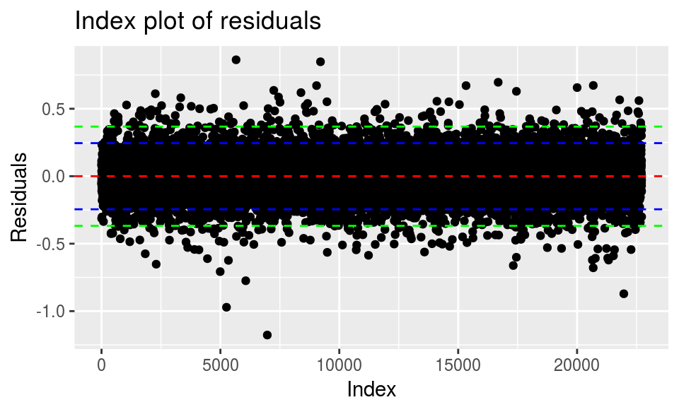

## Lasso Regression

- Now we want to minimise
  $$\text{RSS} + \lambda\sum_{j = 1}^p | \beta_j |$$
  so we penalize the size of the coefficients which may cause some of them to become zero.
- Transformed data: We tuned $\lambda$ and got a value of $8.7084\times 10^{-16}$ and an MSE of 54941789.
- Untransformed data: Here we got $\lambda = 9.5275$ and MSE = 56216154.
- The coefficients for $\texttt{fjeld}$ and $\texttt{svalm2}$ become zero.

## Boosting

- Boosting involves growing decision trees sequentially such that each tree is grown using information from previously grown trees.
- Transformed data: We tuned $\lambda$ and got a value of $0.33$ and MSE = 27786447.
- Untransformed data: Here we got $\lambda = 0.15$ and MSE = 36111501.

$\textbf{Summary}:$

| Method | MSE (log) | MSE (normal) |
| --- | --- | --- |
| Linear | 29136614 | 34703492 |
| Lasso | 54941789 | 56216153 |
| Boosting | 27786447 | 36111501 |

## Classification - Random Forest

| class | Hfj | Kop | Rvk |
| --- | --- | --- | --- |
| Hfj | 1701 | 149 | 658 |
| Kop | 103 | 2447 | 540 |
| Rvk | 134 | 231 | 10079 |

- Most important variables: $\texttt{aldur}$, $\texttt{ummal}$ and $\texttt{ibm2}$

## Support Vector Machine - w/o kernel

- We got $C = 100$ for both data sets.
- Transformed data missclassification error: $23$%.
- Untransformed data missclassification error: $23.23$%.

| class | Hfj | Kop | Rvk |
| --- | --- | --- | --- |
| Hfj | 319 | 48 | 97 |
| Kop | 95 | 545 | 180 |
| Rvk | 329 | 404 | 2997 |

## Support Vector Machine - radial kernel

- Here we got $C = 300$ and $\gamma = 0.1$ for both data sets.
- Transformed data missclassification error: $21.04$%.
- Untransformed data missclassification error: $20.96$%.
- Here the error is slightly lower for the untransformed data.

| class | Hfj | Kop | Rvk |
| --- | --- | --- | --- |
| Hfj | 438 | 68 | 158 |
| Kop | 71 | 629 | 224 |
| Rvk | 234 | 300 | 2892 |

$\textbf{Summary:}$

| Method | MisClass (log) | MisClass (normal) |
| --- | --- | --- |
| Random Forest | 10.83% | 10.9% |
| SVM wo kernel | 23% | 23.23% |
| SVM radial kernel | 21.04% | 20.96% |